# ESA7

Aaliyah Roderer

2024-06-11

## R Markdown

Dieses Dokument beinhaltet die Bearbeitung von ESA 7

## Vorarbeit

```r
# Laden der Bibliotheken
library(dplyr)
library(tidyr)
library(datarium)
library(ggpubr)
```

```r
library(ggplot2)

patient_info <- read.csv("~/Master/Data_Science/ESA7/data/patient_info.csv")
hospital_visit <- read.csv("~/Master/Data_Science/ESA7/data/date.csv")
```

## Task Data Clean:

#### 1. Replace missing BMI values with the median BMI for the corresponding gender.

```r
# BMI median ermitteln
median_bmi_male <- median(patient_info$BMI[patient_info$Sex == "Male"], na.rm = TRUE)
median_bmi_female <- median(patient_info$BMI[patient_info$Sex == "Female"], na.rm = TRUE)

# Ersetzen
for (i in 1:nrow(patient_info)) {
  if (is.na(patient_info$BMI[i])) {
    if (patient_info$Sex[i] == "Male") {
      patient_info$BMI[i] <- median_bmi_male
    } else if (patient_info$Sex[i] == "Female") {
      patient_info$BMI[i] <- median_bmi_female
    }
  }
}
```

#### 2. Perform a sanity check on all columns in both files, and remove any samples that do not pass.

```r
patient_info_clean <- patient_info %>% filter(
     !is.na(Participant_ID) & nchar(Participant_ID) == 7,
     Sex %in% c("Male", "Female"),
     !is.na(Age) & is.numeric(Age) & Age >= 0 & Age <= 120,
     !is.na(BMI) & is.numeric(BMI) & BMI >= 15 & BMI <= 60,
     Smoking_status %in% c("Never", "Previous", "Current", "Prefer not to answer"),
     Disease %in% c(1, 2))

patient_info_clean <- patient_info_clean %>% distinct()

hospital_visit$VisitDate <- as.Date(hospital_visit$VisitDate, format = "%d/%m/%Y")

hospital_visit_clean <- hospital_visit %>%
  filter(
    !is.na(Participant_ID) & nchar(as.character(Participant_ID)) == 7,
    !is.na(VisitDate),
    VisitDate >= as.Date("1950-01-01") & VisitDate <= as.Date("2023-12-31"))

hospital_visit_clean <- hospital_visit_clean %>% distinct()

# Duplikate in den ID's finden
duplicate_ids_patient_info <- patient_info_clean %>%
  group_by(Participant_ID) %>%
  filter(n() > 1) %>%
  ungroup()

duplicate_ids_hospital_visit <- hospital_visit_clean %>%
  group_by(Participant_ID) %>%
  filter(n() > 1) %>%
  ungroup()

# Anzeigen der doppelten IDs zum prüfen ob es Dopplungen gibt die entfernt werden müssen
print("Doppelte Patient_IDs in Patient_information:")
```

```
## [1] "Doppelte Patient_IDs in Patient_information:"
```

```r
print(duplicate_ids_patient_info)
```

```
## # A tibble: 0 × 6
## # ℹ 6 variables: Participant_ID <int>, Sex <chr>, Age <int>,
## #   Smoking_status <chr>, BMI <dbl>, Disease <int>
```

```r
print("Doppelte Patient_IDs in Hospital_Visit:")
```

```
## [1] "Doppelte Patient_IDs in Hospital_Visit:"
```

```r
print(duplicate_ids_hospital_visit)
```

```
## # A tibble: 1,097 × 2
##    Participant_ID VisitDate
##             <int> <date>
##  1        1003300 2022-07-01
##  2        1003300 2021-10-27
##  3        1005551 2021-08-25
##  4        1005551 2021-06-29
##  5        1005624 2021-12-16
##  6        1005624 2007-05-23
##  7        1008931 2021-07-26
##  8        1008931 2021-06-28
##  9        1010841 2020-04-25
## 10        1010841 2006-06-26
## # ℹ 1,087 more rows
```

Die einzelnen Spalten der Tabellen wurden geprüft auf fehlende oder unzulässige Werte. Außerdem wurde auch nach Dopplungen gesucht.

#### 3. Calculate the number of visits each patient made since 1/1/2020. If the Visit Date is missing, it indicates no visits during this period.

```r
visits_since_2020 <- hospital_visit %>%
  filter(!is.na(VisitDate) & VisitDate >= as.Date("2020-01-01")) %>%
  group_by(Participant_ID) %>%
  summarize(Number_of_visits = n())

# nochmal prüfen, ob es fehlende Besuchsdaten gibt um 0 einzutragen
missing_visits <- hospital_visit %>%
  filter(is.na(VisitDate)) %>%
  distinct(Participant_ID) %>%
  mutate(Number_of_visits = 0)

visits_since_2020 <- bind_rows(visits_since_2020, missing_visits)
```

Die einzelnen Besuchsdaten ab dem gegebenen Datum wurden zusammengezählt und in einer Tabelle gesammelt. Außerdem wurde auch nach fehlenden Daten ermittelt, um eine 0 einzutragen.

#### 4. Create a summary table and/or chart showing the number of visits for each month (irrespective of the year).

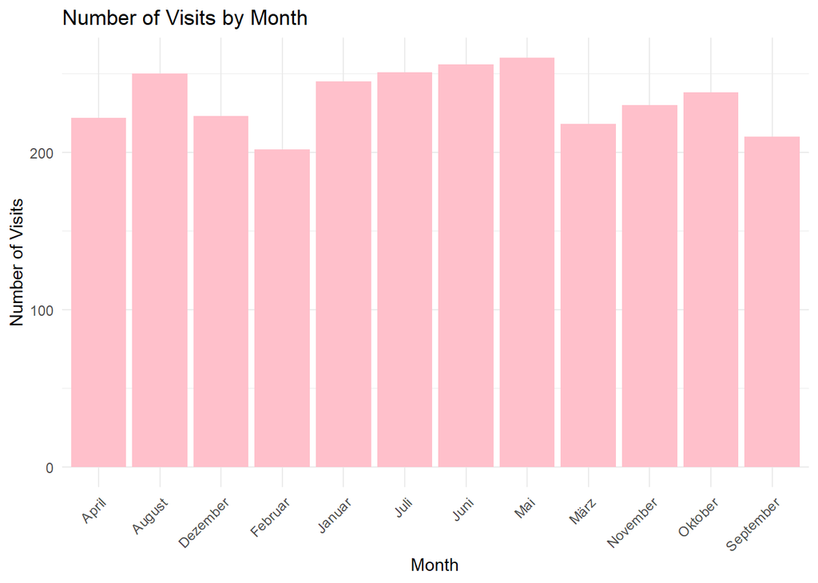

```r
hospital_visit_month <- hospital_visit_clean %>%
  mutate(VisitMonth = format(VisitDate, "%B"))  # %B gibt den Monatsnamen zurück

# Gruppieren der Daten nach Monat und zählen der Besuche
visits_by_month <- hospital_visit_month %>%
  group_by(VisitMonth) %>%
  summarize(Count_of_visits = n())

#Säulendiagramm
ggplot(visits_by_month, aes(x = VisitMonth, y = Count_of_visits)) +
  geom_bar(stat = "identity", fill = "pink") +
  labs(title = "Number of Visits by Month", x = "Month", y = "Number of Visits") +
  theme_minimal() +
  theme(axis.text.x = element_text(angle = 45, hjust = 1))
```

Es wurde eine zusammengefasste Tabelle erstellt und im folgenden noch ein Säulendiagramm zur Visualisierung der Ergebnisse gewählt.

#### 5. add a new column “age group” to split the age to 5 categories: 40-49, 50-59, 60-69, and above 70)

```r
age_breaks <- c(40, 49, 59, 69, Inf)
age_labels <- c("40-49", "50-59", "60-69", "70+")

patient_info_clean <- patient_info_clean %>%
  mutate(age_group = cut(Age, breaks = age_breaks, labels = age_labels, include.lowest = TRUE))
```

Die Altersgruppen wurden über Breaks in einzelne Abschnitte eingeteilt und der Tabelle als Spalte hinzugefügt.

#### 6. Merge the two files to include the columns: Patient_ID, Sex, Age, BMI, Smoking_status, Number_of_visits, Disease and age group

```r
merged_data <- merge(patient_info_clean, visits_since_2020, by = "Participant_ID", all.x = TRUE)

merged_data$Number_of_visits[is.na(merged_data$Number_of_visits)] <- 0
```

## Data Statistics

#### 1. Compare the BMI between the healthy and control groups using a box or violin plot.

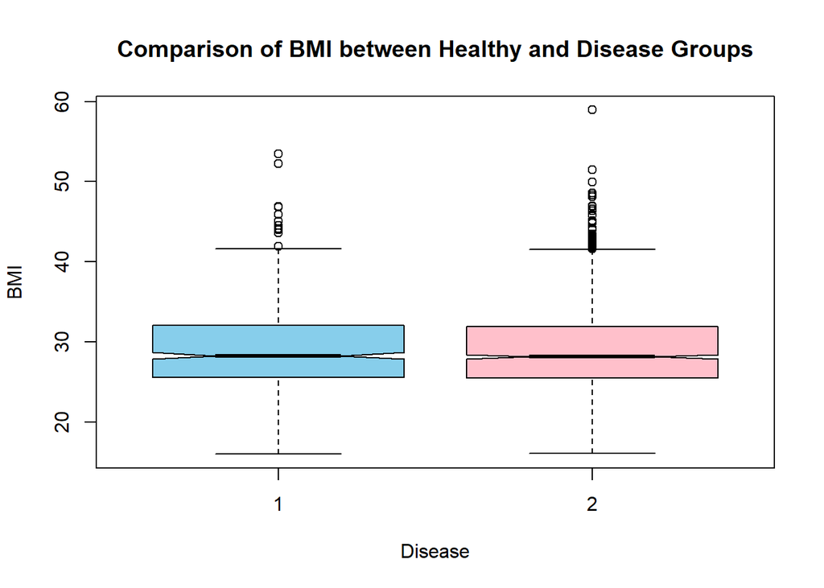

```r
# Boxplot
boxplot(BMI ~ Disease, data = merged_data,
        xlab = "Disease", ylab = "BMI",
        main = "Comparison of BMI between Healthy and Disease Groups",
        col = c("skyblue", "pink"),
        notch = TRUE)  # Notch zeigt den Konfidenzintervall der Medianen an
```

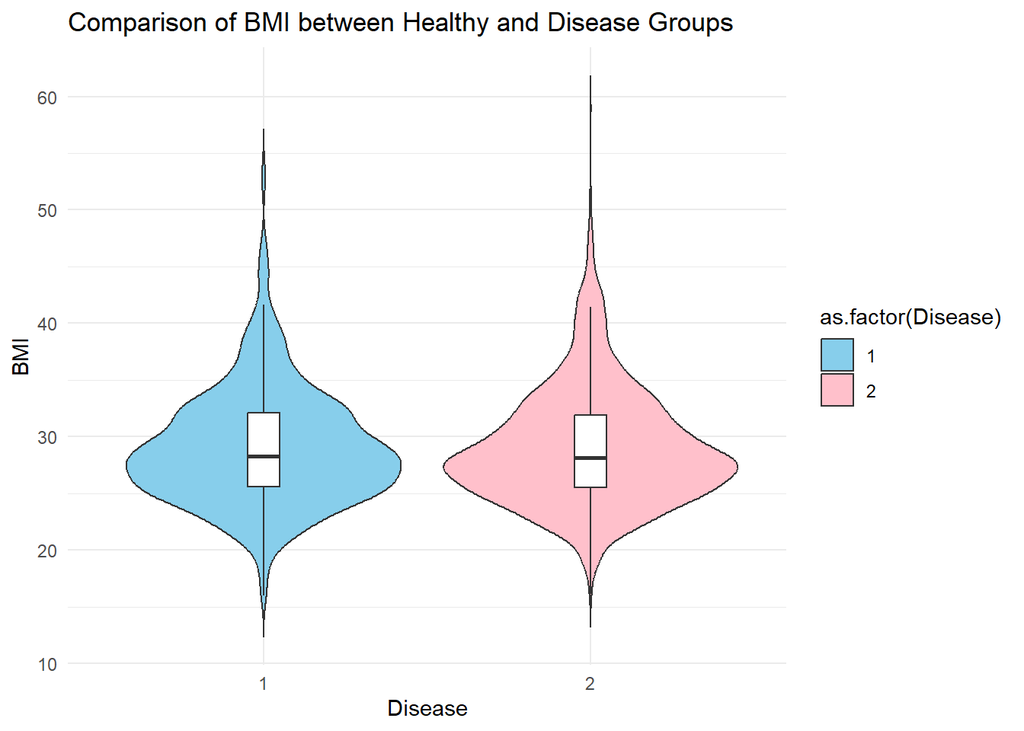

```r
# Violinplot
ggplot(merged_data, aes(x = as.factor(Disease), y = BMI, fill = as.factor(Disease))) +
  geom_violin(trim = FALSE) +
  geom_boxplot(width = 0.1, fill = "white", outlier.shape = NA) +
  labs(x = "Disease", y = "BMI",
       title = "Comparison of BMI between Healthy and Disease Groups") +
  scale_fill_manual(values = c("skyblue", "pink")) +
  theme_minimal()
```

#### 2. Examine if the proportion of smoking status differs between the healthy and control groups.

```r
smoking_table <- table(merged_data$Disease, merged_data$Smoking_status)

# Chi-Quadrat-Test
chi_sq_test <- chisq.test(smoking_table)
# Anzeigen der Ergebnisse
print(chi_sq_test)
```

```
##
##  Pearson's Chi-squared test
##
## data:  smoking_table
## X-squared = 4.4425, df = 3, p-value = 0.2175
```

Da der p-Wert (0.2175) größer als das übliche Signifikanzniveau von 0,05 ist, gibt es nicht ausreichenden Beweise, um die Nullhypothese abzulehnen. Daher gibt es keine ausreichenden Beweise dafür, dass die Proportionen der Raucherstatus zwischen den gesunden und kranken Gruppen unterschiedlich sind. Die Daten liefern also keinen Hinweise darauf, dass sich die Raucherstatus-Proportionen zwischen den gesunden und kranken Gruppen signifikant unterscheiden.

#### 3. Analyze the relationship between smoking status and the number of hospital visits, separately for the disease and healthy groups, and for the overall population.

```r
# Ungesunde Gruppe
disease_group <- merged_data %>%
  filter(Disease == 1) %>%
  group_by(Smoking_status) %>%
  summarize(mean_visits = mean(Number_of_visits))

# Gesunde Gruppe
healthy_group <- merged_data %>%
  filter(Disease == 2) %>%
  group_by(Smoking_status) %>%
  summarize(mean_visits = mean(Number_of_visits))

# Gesamtpopulation
overall_population <- merged_data %>%
  group_by(Smoking_status) %>%
  summarize(mean_visits = mean(Number_of_visits))

# Anzeigen der Ergebnisse
print("Durchschnittliche Anzahl der Krankenhausbesuche für die Gruppe mit Krankheit:")
```

```
## [1] "Durchschnittliche Anzahl der Krankenhausbesuche für die Gruppe mit Krankheit:"
```

```r
print(disease_group)
```

```
## # A tibble: 4 × 2
##   Smoking_status       mean_visits
##   <chr>                      <dbl>
## 1 Current                    0.315
## 2 Never                      0.416
## 3 Prefer not to answer       0.2
## 4 Previous                   0.323
```

```r
print("Durchschnittliche Anzahl der Krankenhausbesuche für die gesunde Gruppe:")
```

```
## [1] "Durchschnittliche Anzahl der Krankenhausbesuche für die gesunde Gruppe:"
```

```r
print(healthy_group)
```

```
## # A tibble: 4 × 2
##   Smoking_status       mean_visits
##   <chr>                      <dbl>
## 1 Current                    0.341
## 2 Never                      0.355
## 3 Prefer not to answer       0.25
## 4 Previous                   0.364
```

```r
print("Durchschnittliche Anzahl der Krankenhausbesuche für die Gesamtpopulation:")
```

```
## [1] "Durchschnittliche Anzahl der Krankenhausbesuche für die Gesamtpopulation:"
```

```r
print(overall_population)
```

```
## # A tibble: 4 × 2
##   Smoking_status       mean_visits
##   <chr>                      <dbl>
## 1 Current                    0.334
## 2 Never                      0.371
## 3 Prefer not to answer       0.222
## 4 Previous                   0.353
```

In der ungesunden Gruppe haben Personen, die nie geraucht haben, die höchste durchschnittliche Anzahl von Krankenhausbesuchen, während diejenigen, die nicht antworten möchten, die geringste Anzahl von Besuchen aufweisen.

In der gesunden Gruppe haben frühere Raucher die höchste durchschnittliche Anzahl von Krankenhausbesuchen, gefolgt von Personen, die nie geraucht haben. Die geringste Anzahl von Besuchen haben diejenigen, die nicht antworten möchten.

In der Gesamtpopulation haben Personen, die nie geraucht haben, die höchste durchschnittliche Anzahl von Krankenhausbesuchen, gefolgt von früheren Rauchern. Personen, die nicht antworten möchten, haben die geringste Anzahl von Krankenhausbesuchen.

Im Allgemeinein zeigt sich, dass die Anzahl der Krankenhausbesuche leicht variiert je nach Rauchstatus. In der ungesunden Gruppe haben Personen, die nie geraucht haben, die meisten Krankenhausbesuche und in der gesunden Gruppe haben frühere Raucher die meisten Krankenhausbesuche. Über die gesamte Population hinweg haben jedoch Nichtraucher die meisten Krankenhausbesuche, während Personen, die nicht antworten möchten, die wenigsten Besuche haben. Diese Ergebnisse könnten darauf hinweisen, dass Nichtraucher möglicherweise häufiger wegen anderer Gesundheitsprobleme ins Krankenhaus gehen, oder dass andere Faktoren als das Rauchen die Häufigkeit der Krankenhausbesuche beeinflussen.

#### 4. Determine if the number of visits is higher in the disease group compared to the healthy group.

```r
disease_visits <- merged_data$Number_of_visits[merged_data$Disease == 1]
healthy_visits <- merged_data$Number_of_visits[merged_data$Disease == 2]

# t-test
t_test_result <- t.test(disease_visits, healthy_visits, alternative = "greater")

# Anzeigen der Ergebnisse
print(t_test_result)
```

```
##
##  Welch Two Sample t-test
##
## data:  disease_visits and healthy_visits
## t = -0.030032, df = 991.11, p-value = 0.512
## alternative hypothesis: true difference in means is greater than 0
## 95 percent confidence interval:
##  -0.04855892         Inf
## sample estimates:
## mean of x mean of y
## 0.3557522 0.3566221
```

T-Wert: Der t-Wert beträgt -0.030032. Ein kleinerer t-Wert deutet darauf hin, dass der Unterschied zwischen den Gruppen (Krank und Gesund) gering ist.

Freiheitsgrade: Die Freiheitsgrade (df) betragen 991.11

P-Wert: Der p-Wert beträgt 0.512. Ein p-Wert größer als das übliche Signifikanzniveau von 0,05 deutet darauf hin, dass es keine ausreichenden Beweise gibt, um die Nullhypothese abzulehnen. Ein p-Wert von 0.512 bedeutet also, dass die Anzahl der Besuche zwischen der Krankheits- und der Gesundheitsgruppe nicht signifikant unterschiedlich ist.

Konfidenzintervall: Das 95%-Konfidenzintervall für die Differenz der Mittelwerte liegt zwischen -0.04855892 und unendlich. Dies bedeutet, dass man mit 95% Sicherheit sagen kann, dass die Differenz der Mittelwerte zwischen den Gruppen zwischen -0.04855892 und unendlich liegt.

Stichprobenmittelwerte: Die Mittelwerte der Stichproben sind 0.3557522 für die Krankheitsgruppe und 0.3566221 für die gesunde Gruppe.

Insgesamt deutet dieses Ergebnis darauf hin, dass es keine ausreichenden Beweise gibt, um zu sagen, dass die Anzahl der Besuche in der Krankheitsgruppe signifikant höher ist als in der gesunden Gruppe, da der p-Wert größer als das übliche Signifikanzniveau ist. Die Mittelwerte der Besuche in den beiden Gruppen sind auch sehr ähnlich.

#### 5. Calculate the disease prevalence (number of sick / total number population) across different age groups in our dataset, and test if the prevalence is different across the group

```r
total_counts <- merged_data %>%
  group_by(age_group) %>%
  summarize(total = n()) %>%
  complete(age_group = unique(merged_data$age_group), fill = list(total = 0))

disease_counts <- merged_data %>%
  filter(Disease == 1) %>%
  group_by(age_group) %>%
  summarize(count = n()) %>%
  complete(age_group = unique(merged_data$age_group), fill = list(count = 0))

disease_counts <- disease_counts[order(disease_counts$age_group),]
total_counts <- total_counts[order(total_counts$age_group),]

total_disease <- sum(disease_counts$count)
expected_counts <- total_disease * (total_counts$total / sum(total_counts$total))
prevalence <- disease_counts$count / total_counts$total

# Anzeigen der Ergebnisse
cat("Disease prevalence across different age groups:\n")
```

```
## Disease prevalence across different age groups:
```

```r
print(prevalence)
```

```
## [1] 0.2709677 0.2173038 0.2672357 0.2285714 0.0000000
```

```r
contingency_table <- merged_data %>%
  group_by(age_group, Disease) %>%
  summarize(count = n()) %>%
  spread(Disease, count, fill = 0)
contingency_matrix <- as.matrix(contingency_table[, -1])

# Chi-Quadrat-Test
chi_sq_test <- chisq.test(contingency_matrix)
# Ausgabe der Testergebnisse
cat("Chi-Quadrat-Test der Unabhängigkeit:\n")
```

```
## Chi-Quadrat-Test der Unabhängigkeit:
```

```r
print(chi_sq_test)
```

```
##
##  Pearson's Chi-squared test
##
## data:  contingency_matrix
## X-squared = 5.5856, df = 4, p-value = 0.2323
```

Die vorliegenden Ergebnisse zeigen die Prävalenz der Krankheit über verschiedene Altersgruppen hinweg:

40-49 Jahre: Die Prävalenz beträgt etwa 27,10%. Dies bedeutet, dass etwa 27,10% der Personen in dieser Altersgruppe erkrankt sind. 50-59 Jahre: Die Prävalenz beträgt etwa 21,73%. Hier ist der Anteil der Erkrankten etwas niedriger als in der Altersgruppe 40-49 Jahre. 60-69 Jahre: Die Prävalenz beträgt etwa 26,72%. Dies zeigt eine leichte Zunahme der Prävalenz im Vergleich zur Altersgruppe 50-59 Jahre. 70+ Jahre: Die Prävalenz beträgt etwa 22,86%. Diese Altersgruppe zeigt eine weitere leichte Abnahme der Prävalenz im Vergleich zur Altersgruppe 60-69 Jahre.

Basierend auf dem Chi-Quadrat-Test ist zu schlussfolgern, dass die Krankheitsprävalenz in den verschiedenen Altersgruppen nicht signifikant unterschiedlich ist. Das bedeutet, dass das Auftreten der Krankheit nicht stark mit dem Alter der Personen in Ihrer Stichprobe zusammenhängt.